# Listening to sad music during induced sadness

## Johnson Neyman

As there are two levels to the timepoint factor we can look at the Johnson Neyman interval for rumination to indicate at what point of rumination an increase significantly predicted.

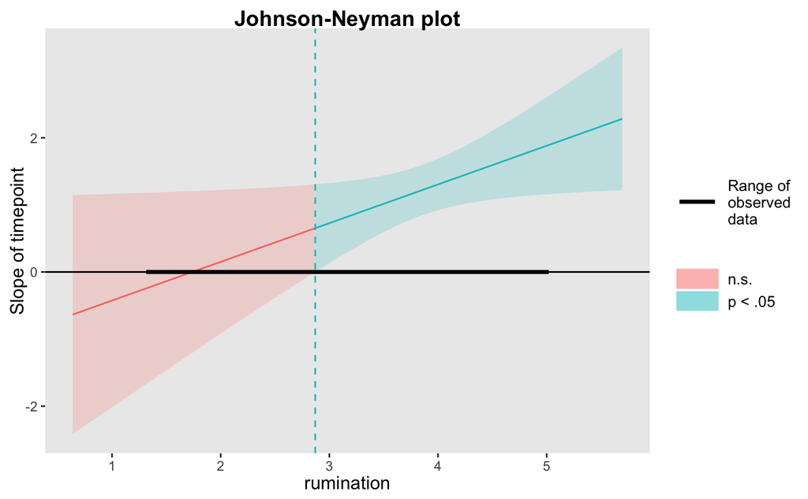

[figure not shown]

```r
jn_rum$plot
jn_rum$plot

quantile(
  data$rumination,
  probs = seq(0, 1, .05)
)
```

```
      0%       5%      10%      15%      20%      25%      30%      35%      40%
1.333333 2.583333 3.000000 3.250000 3.333333 3.500000 3.583333 3.666667 3.750000
     45%      50%      55%      60%      65%      70%      75%      80%      85%
3.833333 3.916667 4.000000 4.083333 4.166667 4.250000 4.333333 4.416667 4.583333
     90%      95%     100%
4.741667 4.916667 5.000000
```

Results in supplment 1 suggest including the mechanisms of entrainment, conditioning, memory, and contagion as control variables.

I have also add a model that has gender and baseline as these values also correlated with rumination

```r
demo_glm <- lmer(
  formula = sadness ~
    timepoint*baseline +
    timepoint*gender +
    timepoint*rumination +
    (1|id),
  data = data_long
)

brecvema_glm <- lmer(
  formula = sadness ~
    timepoint * rumination +
    timepoint * entrainment +
    timepoint * conditioning +
    timepoint * contagion +
    timepoint * memory +
      (1|id),
    data = data_long
)

demo_brecvema_glm <- lmer(
  formula = sadness ~
    timepoint * rumination +
    timepoint * baseline +
    timepoint * gender +
    timepoint * musebaq +
    timepoint * entrainment +
    timepoint * conditioning +
    timepoint * contagion +
    timepoint * memory +
    timepoint * reg_use_1 +
      (1|id),
    data = data_long
)

contagion_demo <- lmer(
  formula = sadness ~
    timepoint * baseline +
    timepoint * gender +
    timepoint * rumination +
    timepoint * contagion +
    timepoint * memory +
    timepoint * conditioning +
      (1|id),
    data = data_long
)
```